# Git Commit Size Analysis

Report Date: 2020-05-22

#### Analysis of Project User Commit Sizes (Number of Commits, Number File Changes, Number of Line Changes)

- The plot titled “Overall User Commit Actions versus User File Commit Actions” shows the number of commit actions performed by each user versus the number of files committed by the same user.
- The plot titled “Overall User Commit Actions versus User Line Changes in Commits” shows the number of commit actions performed by each user versus the number of lines changed (added and deleted combined) in commits by the same user.
- The plot titled “Overall User File Commit Actions versus User Line Changes in Commits” shows the number of files committed by each user versus the number of lines changed (added and deleted combined) in commits by the same user.

#### Analysis Interpretation:

The data is plotted centered on the mean values and scaled by the sample standard deviations. (Data is transformed using the statistical Z-transformation.) Across many commits, differences in the size of commits (with respect to the number of commit actions performed, number of files committed, and number of lines changed per commit) by users provides insight regarding configuration management processes on the project. Based on the available data:

- The number of commits made on the project is **extremely unlikely** to represent a stable process, (p-value = 0.0000000000000000000000037).
- The number of file changes in commits made on the project is **extremely unlikely** to represent a stable process, (p-value = 0.0000000000000000000000037).
- The number of line changes in commits made on the project is **extremely unlikely** to represent a stable process, (p-value = 0.0000000000000000000000037).

Process differences are depicted by a dot representing the user being inside, between, or outside a set of concentric circles in the next three diagrams:

- User points outside both circles indicate that the project may be highly dependent on these users. Dependencies may lead to a process bottleneck or increased risk of process breakdowns in the event these users are not available.
- Data points outside the inner circle but inside the outer circle represent users who are somewhat different in their commit actions versus other users. Monitoring of the reason for these differences is recommended.
- Data points within the inner circle represents personnel performing commits who are similar in their actions to other personnel performing commits.

**Further investigation of the reason for these differences is *recommended*.**

Possible reasons for the differences include:

- Some users have been involved with the project for much longer than the typical user.
- Some users have been designated by the project as being responsible for commits with respect to changes made by other users. (Compare the user commits size analysis with the “Analysis of Project User Changes” for further insight based on the person making the actual changes.)
- Some users are more productive or perform more commits for some other reason than the typical user.

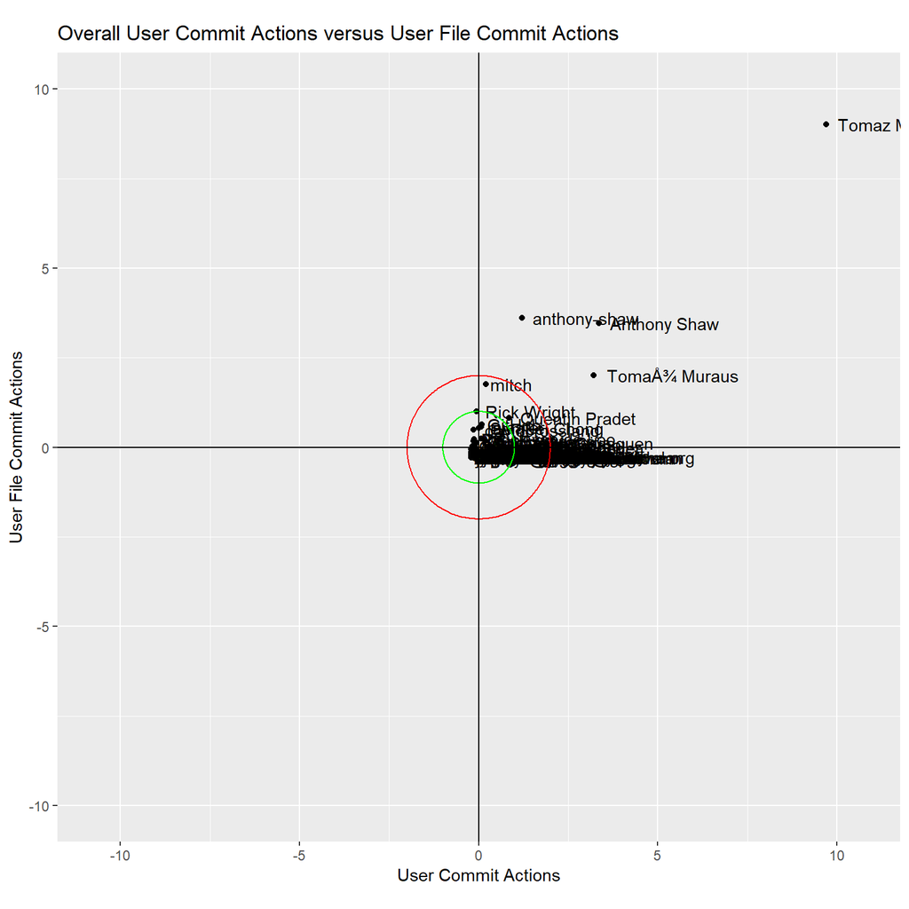

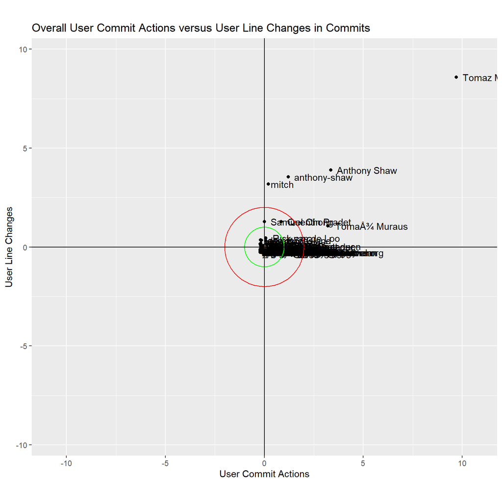

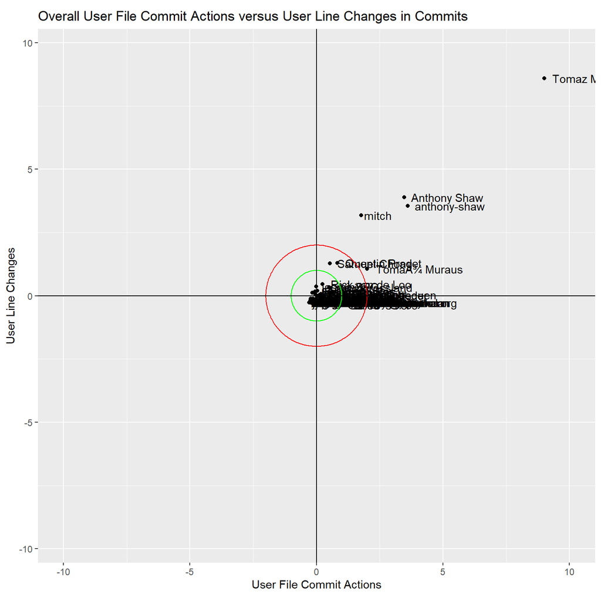

#### Supporting Data

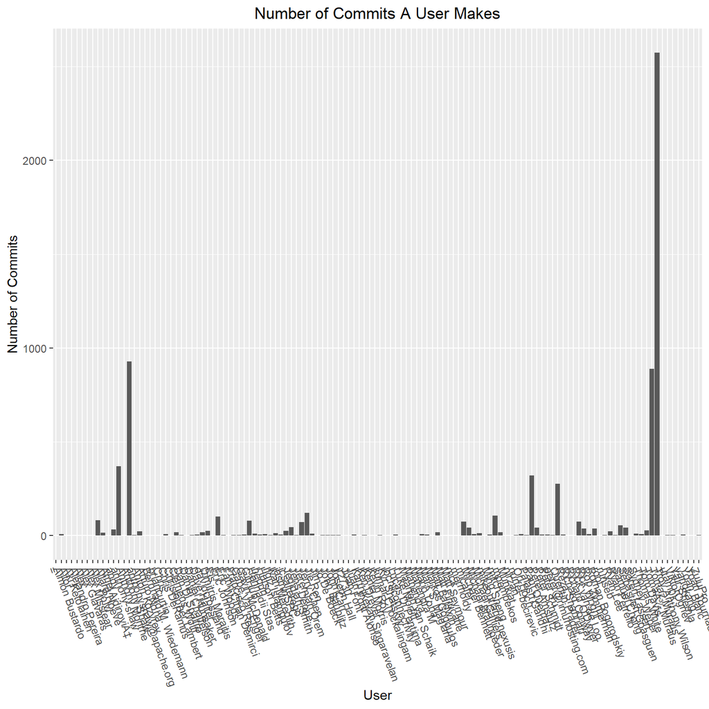

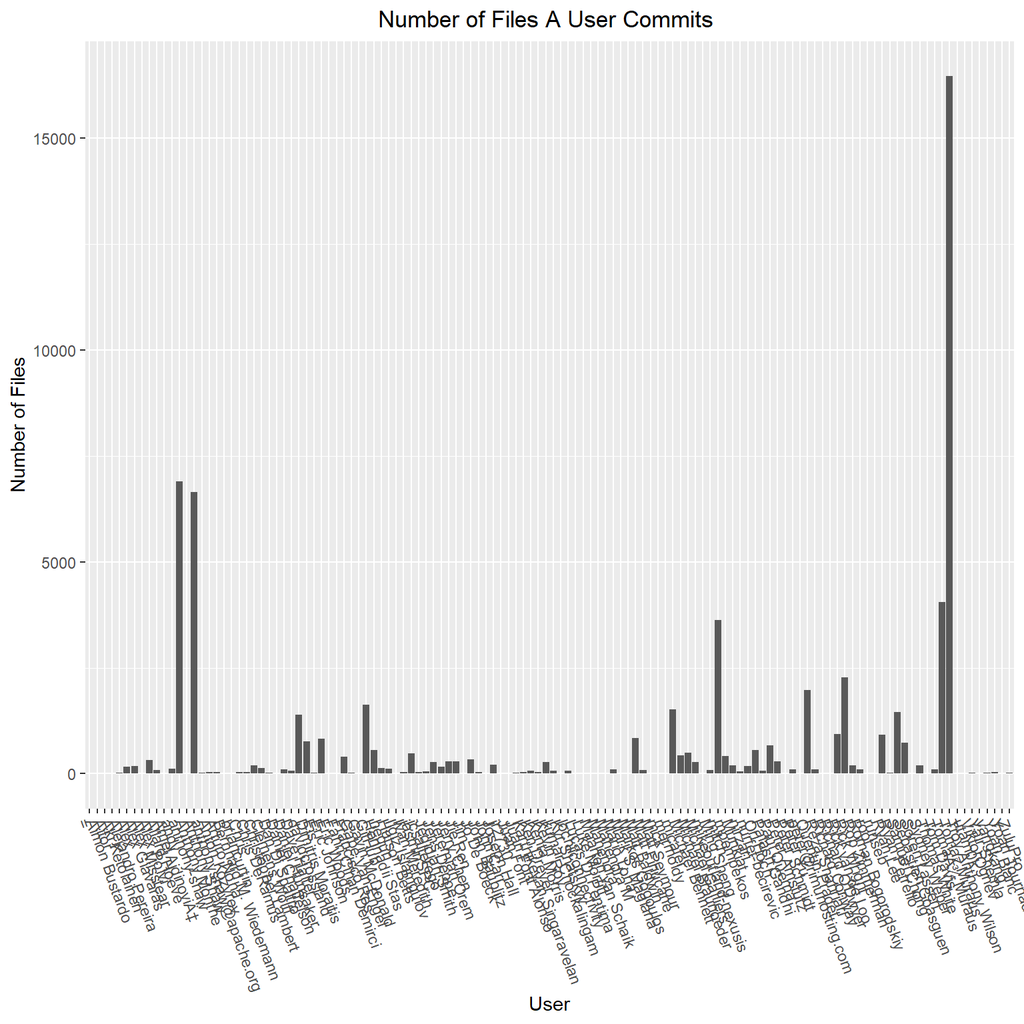

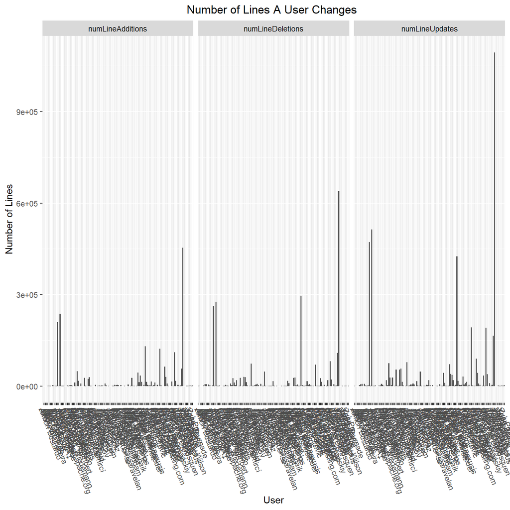